# Project Python Foundations: FoodHub Data Analysis

## Observations on Restaurant Name

```python
#Find the number of unique restaurants
df['restaurant_name'].nunique()
```

```
178
```

There are 178 unique restaurants in the dataset

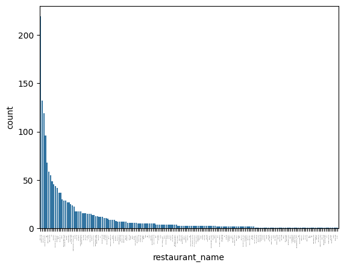

```python
# Graph the count of restaurant name in the dataset
sns.countplot(data=df, x='restaurant_name', order=df['restaurant_name'].value_counts().index[:178])
#rotate x-sticks
plt.xticks(rotation=90)
plt.xticks(fontsize=.5)

plt.show()
```

This is a difficult graph to read, so we can look at the top 25 restaurants by count.

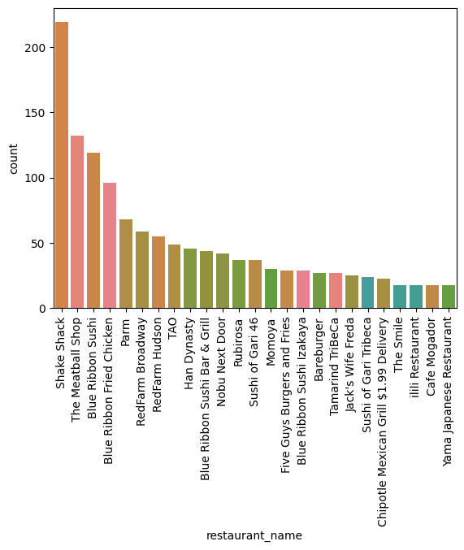

```python
# Graph of top 25 most popular restaurants by order count
sns.countplot(data=df, x='restaurant_name', order=df['restaurant_name'].value_counts().index[:25],hue='restaurant_name')
#rotate x-sticks
plt.xticks(rotation=90)
# Decrease font of x-axis
plt.xticks(fontsize=10)
plt.show()
```

Observation:

```python
#Make a count for top 25 restaurants
df['restaurant_name'].value_counts().head(25)
```

```
restaurant_name
Shake Shack                              219
The Meatball Shop                        132
Blue Ribbon Sushi                        119
Blue Ribbon Fried Chicken                 96
Parm                                      68
RedFarm Broadway                          59
RedFarm Hudson                            55
TAO                                       49
Han Dynasty                               46
Blue Ribbon Sushi Bar & Grill             44
Nobu Next Door                            42
Rubirosa                                  37
Sushi of Gari 46                          37
Momoya                                    30
Five Guys Burgers and Fries               29
Blue Ribbon Sushi Izakaya                 29
Bareburger                                27
Tamarind TriBeCa                          27
Jack's Wife Freda                         25
Sushi of Gari Tribeca                     24
Chipotle Mexican Grill $1.99 Delivery     23
The Smile                                 18
ilili Restaurant                          18
Cafe Mogador                              18
Yama Japanese Restaurant                  18
Name: count, dtype: int64
```

```python
# Find the percentage of top 25 restaurants by order count
df['restaurant_name'].value_counts().head(25) / df.shape[0] * 100
```

```
restaurant_name
Shake Shack                              11.538462
The Meatball Shop                         6.954689
Blue Ribbon Sushi                         6.269758
Blue Ribbon Fried Chicken                 5.057956
Parm                                      3.582719
RedFarm Broadway                          3.108535
RedFarm Hudson                            2.897787
TAO                                       2.581665
Han Dynasty                               2.423604
Blue Ribbon Sushi Bar & Grill             2.318230
Nobu Next Door                            2.212856
Rubirosa                                  1.949420
Sushi of Gari 46                          1.949420
Momoya                                    1.580611
Five Guys Burgers and Fries               1.527924
Blue Ribbon Sushi Izakaya                 1.527924
Bareburger                                1.422550
Tamarind TriBeCa                          1.422550
Jack's Wife Freda                         1.317176
Sushi of Gari Tribeca                     1.264489
Chipotle Mexican Grill $1.99 Delivery     1.211802
The Smile                                 0.948367
ilili Restaurant                          0.948367
Cafe Mogador                              0.948367
Yama Japanese Restaurant                  0.948367
Name: count, dtype: float64
```

```python
# Sum the percentages of the top 25 restaurants
(df['restaurant_name'].value_counts().head(25) / len(df) * 100).sum()
```

```
67.913593256059
```

Observation: Out of 178 restaurants, the top 25 most popular account for 67.9% of orders.

Other Observations:

21 restaurants have over 20 orders.

Only 7 restaurants have over 50 orders.

3 restaurants have orders over 100.

Only Shake Shack has orders over 200.

# Observations on Cuisine Type

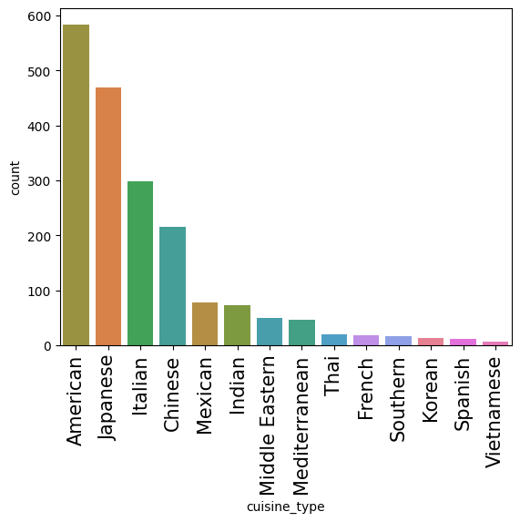

```python
#Countplot for cuisine type in decreasing order by count
sns.countplot(data=df, x='cuisine_type', order=df['cuisine_type'].value_counts().index, hue='cuisine_type')
#rotate x-ticks
plt.xticks(rotation=90)
plt.show()
```

Observation: The most popular type of cuisine is American, followed by Japenese.

```python
# Find the percentage of orders by cuisine type
df['cuisine_type'].value_counts() / df.shape[0] * 100
```

```
cuisine_type
American          30.769231
Japanese          24.762908
Italian           15.700738
Chinese           11.327713
Mexican            4.056902
Indian             3.846154
Middle Eastern     2.581665
Mediterranean      2.423604
Thai               1.001054
French             0.948367
Southern           0.895680
Korean             0.684932
Spanish            0.632244
Vietnamese         0.368809
Name: count, dtype: float64
```

Observations:

The top 4 cuisine types are American, Japanese, Italian, and Chinese. All other cuisine types have less than 100 orders.

American and Japanese acount for over 55% of the orders.

The top 4 cuisine types account for 80% of the total orders!

# Observations on Day of the Week

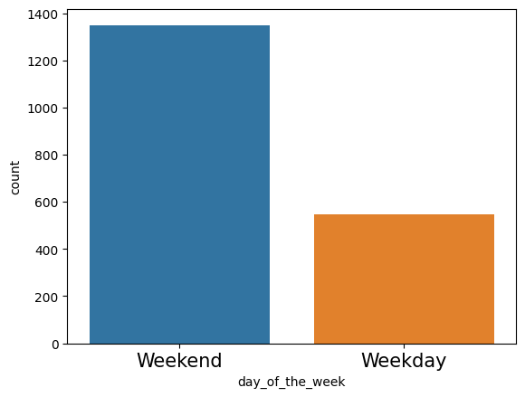

```python
#countplot for Day of the Week
sns.countplot(data=df, x='day_of_the_week', hue='day_of_the_week')
plt.show()
```

```python
# Find the percentage of orders by day of the week
df['day_of_the_week'].value_counts() / df.shape[0] * 100
```

```
day_of_the_week
Weekend    71.18019
Weekday    28.81981
Name: count, dtype: float64
```

Observations:

71.2% of orders happen on the weekend

28.8% of orders happen during the work week.

There are more than twice the number of orders on the weekend.

There is an opportunity to increase orders during the work week. This could be an area for promotion or advertising to increase weekday order volume.

# Observation on Rating

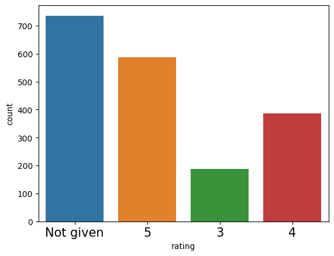

```python
#Countplot for Ratings
sns.countplot(data=df, x='rating', hue='rating')
plt.show()
```

Observations:

Over 700 orders were not rated.

Almost 600 orders were given 5 stars

About 400 orders were given 4 stars

And under 200 orders were given 3 stars

Of the orders given ratings:

- More than half were 5 stars.
- The average rating was between 4 and 5

### **Question 7**: Which are the top 5 restaurants in terms of the number of orders received? [1 mark]

```python
# Write the code here
df['restaurant_name'].value_counts().head(5)
```

```
restaurant_name
Shake Shack                  219
The Meatball Shop            132
Blue Ribbon Sushi            119
Blue Ribbon Fried Chicken     96
Parm                          68
Name: count, dtype: int64
```

#### Observations:

The top five restaurants by orders are:

1. Shake Shack (219)
2. The Meatball Shop (132)
3. Blue Ribbon Sushi (119)
4. Blue Ribbon Fried Chicken (96)
5. Parm (68)

### **Question 8**: Which is the most popular cuisine on weekends? [1 mark]

```python
# Write the code here
df[df['day_of_the_week'] == 'Weekend']['cuisine_type'].value_counts().head(5)
```

```
cuisine_type
American    415
Japanese    335
Italian     207
Chinese     163
Mexican      53
Name: count, dtype: int64
```

#### Observations:

American is the most popular cuisine on the weekends.

### **Question 9**: What percentage of the orders cost more than 20 dollars? [2 marks]

```python
# Write the code here
df[df['cost_of_the_order'] > 20].shape[0] / df.shape[0] * 100
```

```
29.24130663856691
```

#### Observations:

29.24% cost more than $20.

### **Question 10**: What is the mean order delivery time? [1 mark]

```python
# Write the code here
df['delivery_time'].mean()
```

```
24.161749209694417
```

#### Observations:

The average delivery time is 24.16 minutes

### **Question 11:** The company has decided to give 20% discount vouchers to the top 3 most frequent customers. Find the IDs of these customers and the number of orders they placed. [1 mark]

```python
# Write the code here
df['customer_id'].value_counts().head(3)
```

```
customer_id
52832    13
47440    10
83287     9
Name: count, dtype: int64
```

#### Observations:

The top three most frequent customer IDs and orders placed:

52832 placed 13 orders

47440 placed 10 orders

83287 placed 9 orders

### **Question 12**: Perform a multivariate analysis to explore relationships between the important variables in the dataset. (It is a good idea to explore relations between numerical variables as well as relations between numerical and categorical variables) [10 marks]

# Multivariate Analysis between numerical values

```python
#Finding the correlation of numerical variables
numerical_df = df.select_dtypes(include=['number'])
numerical_df.corr()
```

|  | order_id | customer_id | cost_of_the_order | food_preparation_time | delivery_time |
| --- | --- | --- | --- | --- | --- |
| order_id | 1.000000 | -0.013960 | 0.021171 | -0.007026 | 0.009690 |
| customer_id | -0.013960 | 1.000000 | -0.001322 | -0.030330 | -0.009885 |
| cost_of_the_order | 0.021171 | -0.001322 | 1.000000 | 0.041527 | -0.029949 |
| food_preparation_time | -0.007026 | -0.030330 | 0.041527 | 1.000000 | 0.011094 |
| delivery_time | 0.009690 | -0.009885 | -0.029949 | 0.011094 | 1.000000 |

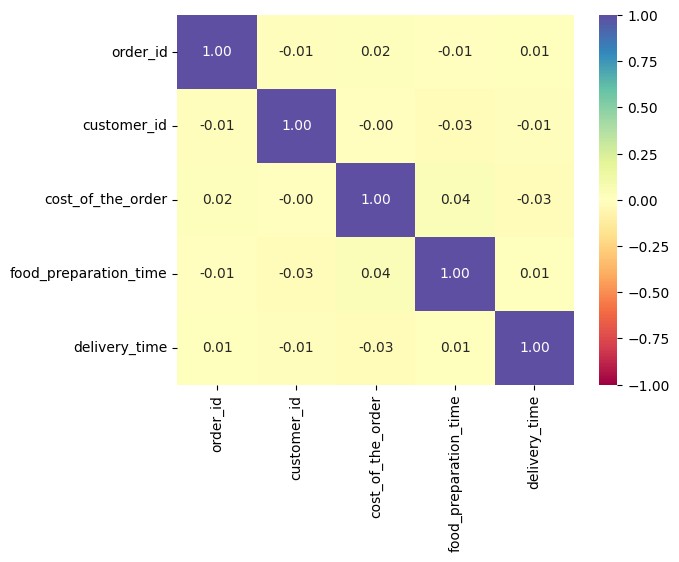

```python
#Create a heatmap of numerical variables
numerical_df = df.select_dtypes(include=['number'])
sns.heatmap(numerical_df.corr(), annot=True, vmin=-1, vmax=1, fmt=".2f", cmap="Spectral")
plt.show()
```

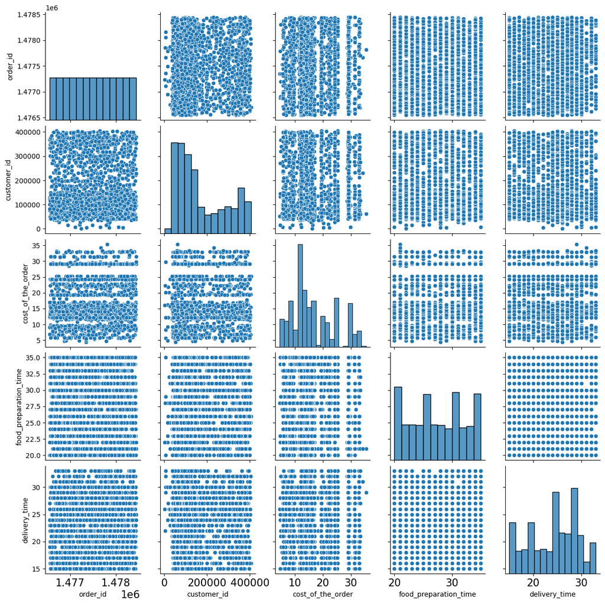

```python
# Pairplot of numerical data use colors
sns.pairplot(numerical_df)
plt.show()
```

Observations of Bivariate Analysis between numerical variables:

After looking at a correlation table, a heatmap, and a pairplot, there are no strong correlations between these numerical variables.

# Multivariate Analysis between Numerical and Categorical Data

# Comparing Cost of the Order and Rating

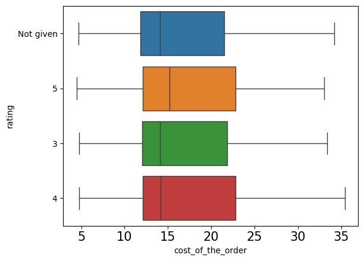

```python
# Compare cost of the order and rating
sns.boxplot(data=df, y='rating', x='cost_of_the_order', hue='rating')
plt.show()
```

Observations: Cost does not seem to have an effect on ratings

# Comparing delivery time and rating

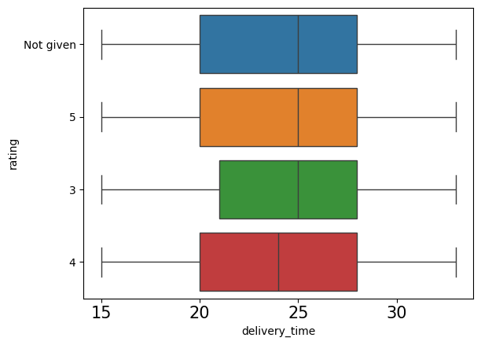

```python
# Compare delivery time and rating
sns.boxplot(data=df, y='rating', x='delivery_time', hue='rating')
plt.show()
```

Observations: Delivery time does not seem to affect ratings.

# Comparing delivery time and day of the week

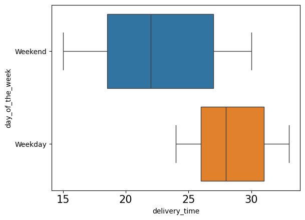

```python
#Compare delivery time and day of the week
sns.boxplot(data=df, y='day_of_the_week', x='delivery_time', hue='day_of_the_week')
plt.show()
```

```python
#Calculate avg delivery time on weekend and weekdays
df.groupby('day_of_the_week')['delivery_time'].mean()
```

```
day_of_the_week
Weekday    28.340037
Weekend    22.470022
Name: delivery_time, dtype: float64
```

Delivery time is 26% slower on the weekdays.

# Comparing day of the week with cost of the order

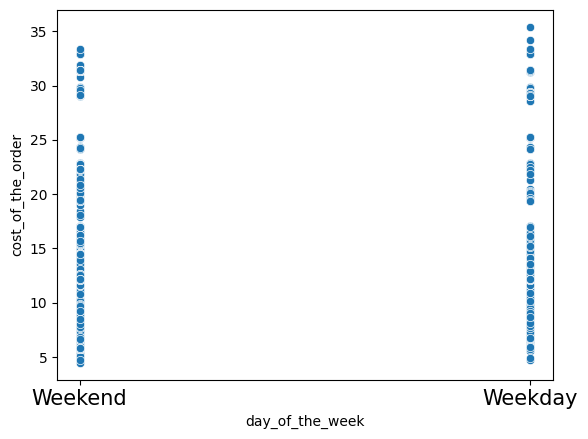

```python
#Make a scatterplot of day of the week and cost of the order
sns.scatterplot(data=df, x='day_of_the_week', y='cost_of_the_order')
plt.show()
```

We will look at a line plot for more insight.

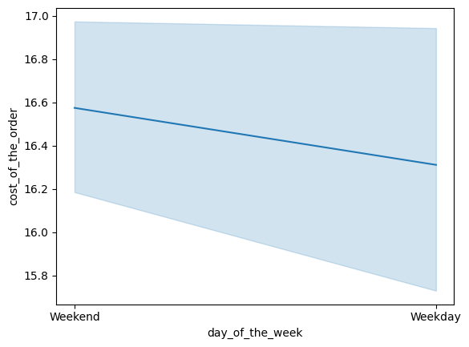

```python
#Make a line plot for day of the week and cost of the order
sns.lineplot(data=df, x='day_of_the_week', y='cost_of_the_order')
plt.show()
```

Now a box plot

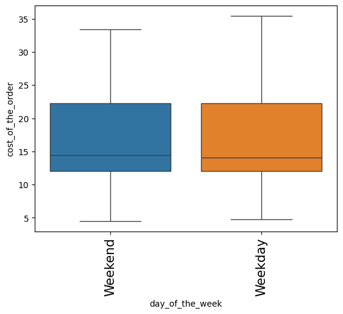

```python
# Dispersion of price by day of the week
sns.boxplot(data=df, x='day_of_the_week', y='cost_of_the_order', hue='day_of_the_week')
plt.xticks(rotation=90)
plt.show()
```

We can see that the average cost of an order is slightly higher on the weekend vs the weekday. The range of cost is slightly higher on weekdays, but not significant. The dispersion of cost is very similar for weekends and weekdays.

# Look at order count on weekdays and weekends by cuisine type

```python
#Count the number of orders by the day of the week for restaurant type
df.groupby(['day_of_the_week', 'cuisine_type']).size()
```

```
day_of_the_week  cuisine_type
Weekday          American          169
                 Chinese            52
                 French              5
                 Indian             24
                 Italian            91
                 Japanese          135
                 Korean              2
                 Mediterranean      14
                 Mexican            24
                 Middle Eastern     17
                 Southern            6
                 Spanish             1
                 Thai                4
                 Vietnamese          3
Weekend          American          415
                 Chinese           163
                 French             13
                 Indian             49
                 Italian           207
                 Japanese          335
                 Korean             11
                 Mediterranean      32
                 Mexican            53
                 Middle Eastern     32
                 Southern           11
                 Spanish            11
                 Thai               15
                 Vietnamese          4
dtype: int64
```

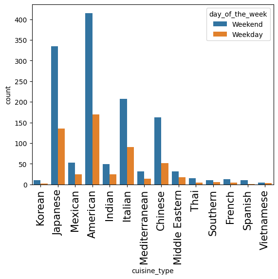

```python
#Graph order count by cuisine type on weekdays and weekends
sns.countplot(data=df, x='cuisine_type', hue='day_of_the_week')
plt.xticks(rotation=90)
plt.show()
```

Conclusions: There is great opportunity to increase orders during the weekdays.

# Analyzing cost of the order by the type of food on weekdays and weekends

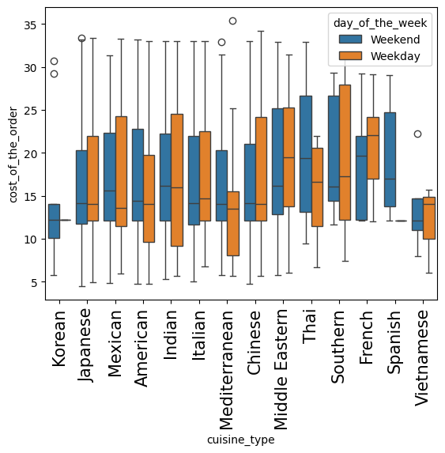

```python
#Dispersion of cost of order by type of food on weekdays and weekends
sns.boxplot(data=df, x='cuisine_type', y='cost_of_the_order', hue='day_of_the_week')

#Make x-ticks vertical
plt.xticks(rotation=90)
plt.show()
```

The 4 most popular cuisine types have similar range of cost and cost dispersion.

# Analyzing cuisine type and delivery time on weekdays and weekends

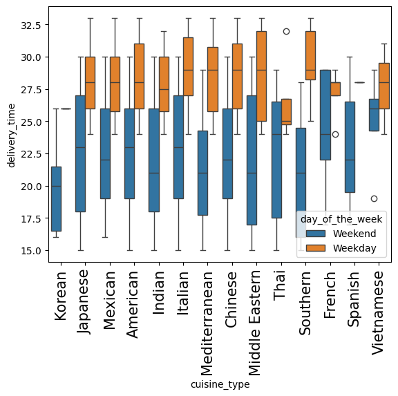

```python
# Compare cuisine type with delivery time on weekdays and weekends

sns.boxplot(data=df, x='cuisine_type', y='delivery_time', hue='day_of_the_week')
plt.xticks(rotation=90)
plt.show()
```

## Observation: Weekend delivery times are faster for all types of cuisine on the weekend.

### **Question 13:** The company wants to provide a promotional offer in the advertisement of the restaurants. The condition to get the offer is that the restaurants must have a rating count of more than 50 and the average rating should be greater than 4. Find the restaurants fulfilling the criteria to get the promotional offer. [3 marks]

```python
#make a new dataframe dropping ratings 'not given'
df_promo = df[df['rating'] != 'Not given']

#Change datatype of rating in df_promo to an integer
df_promo['rating'] = df_promo['rating'].astype(int)

#Checking that the new rating column is dtype integer
df_promo.info()
```

```
<class 'pandas.core.frame.DataFrame'>
Index: 1162 entries, 2 to 1896
Data columns (total 9 columns):
 #   Column                 Non-Null Count  Dtype
---  ------                 --------------  -----
 0   order_id               1162 non-null   int64
 1   customer_id            1162 non-null   int64
 2   restaurant_name        1162 non-null   object
 3   cuisine_type           1162 non-null   object
 4   cost_of_the_order      1162 non-null   float64
 5   day_of_the_week        1162 non-null   object
 6   rating                 1162 non-null   int64
 7   food_preparation_time  1162 non-null   int64
 8   delivery_time          1162 non-null   int64
dtypes: float64(1), int64(5), object(3)
memory usage: 90.8+ KB
```

```python
# Filter the restaurant column for those with rating count greater than 50
popular_restaurants = df_promo.groupby('restaurant_name').filter(lambda x: len(x) > 50)
#Show average rating of popular_restaurants
popular_restaurants.groupby('restaurant_name')['rating'].mean()
```

```
restaurant_name
Blue Ribbon Fried Chicken    4.328125
Blue Ribbon Sushi            4.219178
Shake Shack                  4.278195
The Meatball Shop            4.511905
Name: rating, dtype: float64
```

#### Observations:

The restaurants fulfilling the promotional offer with a rating count > 50 and an average rating > 4 are:

Blue Ribbon Fried Chicken, Blue Ribbon Sushi, Shake Shack, and The Meatball Shop

### **Question 14:** The company charges the restaurant 25% on the orders having cost greater than 20 dollars and 15% on the orders having cost greater than 5 dollars. Find the net revenue generated by the company across all orders. [3 marks]

```python
#Create a conditional function to find net revenue
def net_revenue(cost_of_the_order):
  if cost_of_the_order > 20:
    return cost_of_the_order * 0.25
  elif cost_of_the_order > 5:
    return cost_of_the_order * 0.15
  else:
    return cost_of_the_order * 0
#Add a net_revenue column to the df
df['net_revenue'] = df['cost_of_the_order'].apply(net_revenue)
df.head()
```

|  | order_id | customer_id | restaurant_name | cuisine_type | cost_of_the_order | day_of_the_week | rating | food_preparation_time | delivery_time | net_revenue |
| --- | --- | --- | --- | --- | --- | --- | --- | --- | --- | --- |
| 0 | 1477147 | 337525 | Hangawi | Korean | 30.75 | Weekend | Not given | 25 | 20 | 7.6875 |
| 1 | 1477685 | 358141 | Blue Ribbon Sushi Izakaya | Japanese | 12.08 | Weekend | Not given | 25 | 23 | 1.8120 |
| 2 | 1477070 | 66393 | Cafe Habana | Mexican | 12.23 | Weekday | 5 | 23 | 28 | 1.8345 |
| 3 | 1477334 | 106968 | Blue Ribbon Fried Chicken | American | 29.20 | Weekend | 3 | 25 | 15 | 7.3000 |
| 4 | 1478249 | 76942 | Dirty Bird to Go | American | 11.59 | Weekday | 4 | 25 | 24 | 1.7385 |

Total Net Revenue Calculation

```python
#Sum the net revenue for all oders
sum_net=df['net_revenue'].sum()
sum_net
```

```
6166.303
```

Total Net Revenue = $6,166.30

Average Net Revenue for all Orders

```python
#Find the average net revenue for all orders
df['net_revenue'].mean()
```

```
3.2488424657534245
```

#### Observations:

The total net revenue generated across all orders = $6,166.30

The avg net revenue per order is 3.25

Aside: Calculate net revenue % margin

```python
#Sum cost of the orders
sum_cost=df['cost_of_the_order'].sum()
sum_cost
```

```
31314.82
```

```python
#Find the net_revenue margin
net_revenue_margin = sum_net / sum_cost * 100
net_revenue_margin
```

```
19.691325065895317
```

The net revenue margin is 19.7%

### **Question 15:** The company wants to analyze the total time required to deliver the food. What percentage of orders take more than 60 minutes to get delivered from the time the order is placed? (The food has to be prepared and then delivered.) [2 marks]

```python
# Create a new column in the df for preparation time plus delivery time
df['total_time'] = df['food_preparation_time'] + df['delivery_time']

# Count the number of orders that take more than 60 minutes total time
total_orders = df.shape[0]
late_orders = df[df['total_time'] > 60].shape[0]

# Find the percentage of orders that take more than 60 minutes total time
percentage_late_orders = late_orders / total_orders * 100

print(percentage_late_orders)
```

```
10.537407797681771
```

#### Observations:

10.54% of orders take more than 60 minutes to prepare and deliver to the customer.

### **Question 16:** The company wants to analyze the delivery time of the orders on weekdays and weekends. How does the mean delivery time vary during weekdays and weekends? [2 marks]

```python
#Compare the average time for delivery on weekend days vs week days
df.groupby('day_of_the_week')['delivery_time'].mean()
```

```
day_of_the_week
Weekday    28.340037
Weekend    22.470022
Name: delivery_time, dtype: float64
```

#### Observations:

Delivery times are about 6 miinutes faster on the weekends.

The weekday avg delivery time is 28.34 minutes versus 22.47 minutes on the weekend

### Conclusion and Recommendations

### **Question 17:** What are your conclusions from the analysis? What recommendations would you like to share to help improve the business? (You can use cuisine type and feedback ratings to drive your business recommendations.) [6 marks]

### Conclusions:

- Net Revenue is only coming from the 15% and 25% that is charged to the restaurants based off the cost of the order
- The average net revenue is $3.25 per order in the dataset. This represents a net revenue margin of 19.7%
- Order volume is more than double on the weekends, for almost all cuisine types
- Delivery time is 26% slower on the week days.
- The top 25 restaurants represent 67% of order volume
- American, Japanese, Italian, and Chinese account for 80% of the orders

### Recommendations:

- Increase Net Revenue by charging the customer a flat fee of $3.25 per order. This will ~double revenue with no extra cost to the restaurants.
- Consider a customer loyalty program (i.e reward point) for recurring customers in lieu of the 20% voucher. Market 2X and 3X points for weekday orders to increase volume.

  Also, restaurants/cuisines with lower prep time and delivery time should be incentivised with customer loyalty points. Increasing volume for orders that take less time.
- Focus app advertising at the top 25 restaurants; they account for 67% of your business.
- Provide your promotion to the top 4 restaurants for the week days only. There is an opportunity to increase volume here.
- Provide promotions to offices, business and workplaces to increase volume on the weekdays. Create a market for lunch at the office.
- Increase the number of drivers during the weekdays to lower delivery time.